# final_exam

Stewart Renehan

6/7/2019

## 1

#### a)

The marginal distribution of x is a uniform distribution with probability 1/4 in the range {-4, -2}, and a uniform distribution with probability 1/4 in the range {2, 4}, with probability 0 everywhere else.

#### b)

The bayes rule is
$$f_b(x) = \{1\ if\ -4 < x < -2;\ 2\ if\ 2 < x < 4\}$$

The risk is 0 because there is 0 probability of y = 2 occuring when x is between -4 and -2, and 0 probability of y = 1 occuring if x is between 2 and 4, and 0 probability of observing x outside of these two ranges.

#### c)

If there is at least one observation in each bin, the risk is 0 because when the observed x is -2, the closest possible observation to the y=2 region, the furthest possible training data for the y=1 region is 2 points away, while the closest possible observation for the y = 2 region (which would result in an incorrect prediction) is 4 points away. So, as long as there is at least one trainig data point for y = 1 and at least one training data point for y =2, there is 0 probability of an incorrect prediction.

However, when there are zero training data points in one bin, the risk is nonzero. It is equivalent to the probability of obtaining zero training points in one bin = $(\frac{1}{2})^{n-1}$ times the probability of the test value being in the opposite bin = 1/2.

Thus, the total risk is $(\frac{1}{2})^n$.

#### d)

The total risk is the sum of the two cases, $(n+1)(\frac{1}{2})^n$

#### e)

The one nearest neighbor method has lower risk because misclassifications only happen when one bin has 0 training observations, while the 3 nearest neighbor has misclassifications when one bin has 0 or 1 training observations.

## 2

#### a)

```r
spam.data = read.table('/Users/stewart/Downloads/spam.data')
traintest = read.table('/Users/stewart/Downloads/spam.traintest')

test = spam.data[traintest== 1,]
train = spam.data[traintest==0,]
# install.packages('rpart')
require(rpart)
```

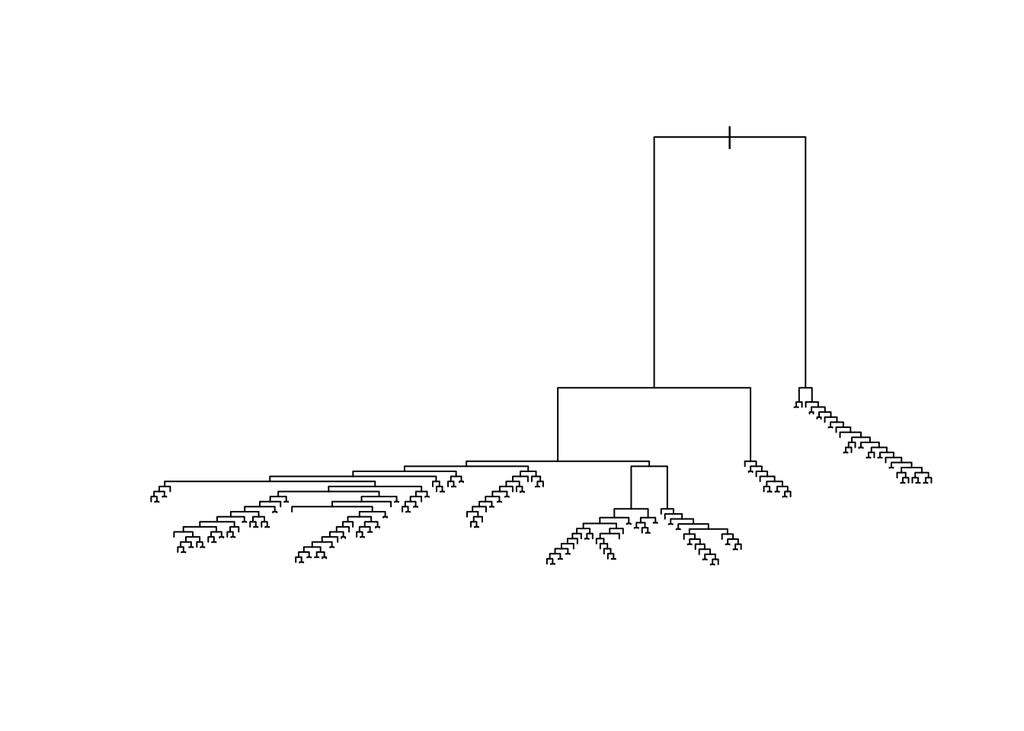

```r
# help(rpart)
model = rpart(V58~., data = train, method="class", cp=0, minsplit=0)
plot(model)
```

```r
print('Cant print the names of the splits, there are too many!')
```

```
## [1] "Cant print the names of the splits, there are too many!"
```

```r
# text(model)

train.error = sum((predict(model, train)[,1] == 0) != train$V58) / nrow(train)
test.error = sum((predict(model, test)[,1] == 0) != test$V58) / nrow(test)
print(paste0('Train Error Rate: ', train.error));
```

```
## [1] "Train Error Rate: 0.000978792822185971"
```

```r
print(paste0('Test Error Rate: ', test.error));
```

```
## [1] "Test Error Rate: 0.083984375"
```

#### b)

```r
folds <- cut(sample(seq(1,nrow(train))),breaks=10,labels=FALSE)
ct.tests = c(0, 0.00001, 0.0001, 0.001, 0.01, 0.1, 1);
errors = c();
for (lambda in ct.tests) {
  val.errors = c();
  for (fold in 1:10) {
    model =  rpart(V58~., data = train[folds !=fold,], method='class', cp=lambda, minsplit=0);
    val.error = sum((predict(model, train[fold == fold,])[,1] == 0) != train[fold == fold,]$V58) / nrow(train[fold == fold,]);
    val.errors = c(val.errors, val.error);
  }
  errors = c(errors, mean(val.errors))
  print(mean(val.errors))
}
```

```
## [1] 0.01050571
## [1] 0.01050571
## [1] 0.01050571
## [1] 0.3701468
## [1] 0.3973899
## [1] 0.3973899
## [1] 0.3973899
```

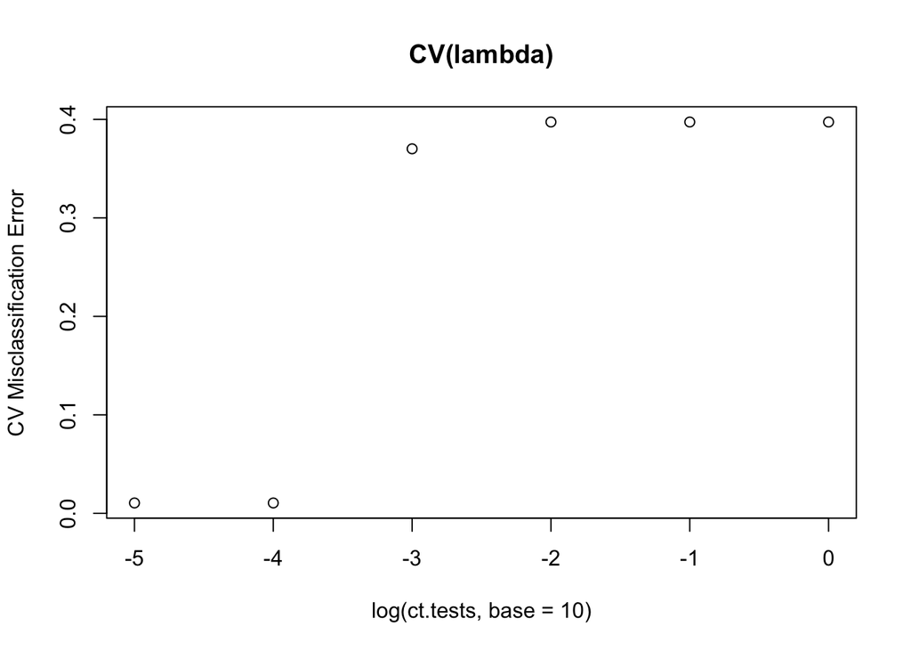

```r
plot(log(ct.tests, base=10), errors, ylab='CV Misclassification Error', main='CV(lambda)');
```

```r
print(paste0('Optimal lambda', 0.0001))
```

```
## [1] "Optimal lambda1e-04"
```

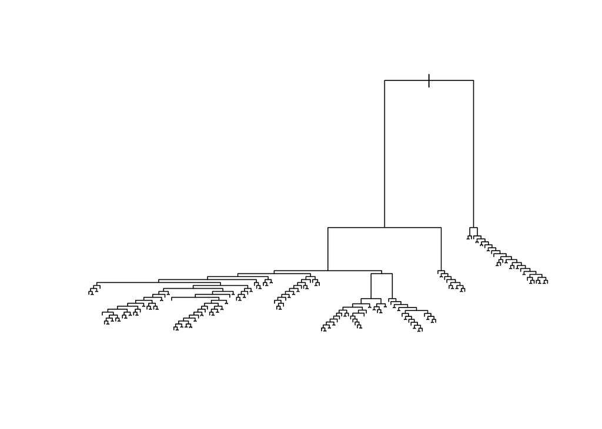

```r
model.optimal = rpart(V58~., data = train, method='class', cp=0.0001, minsplit=0)
plot(model.optimal)
```

```r
train.error = sum((predict(model.optimal, train)[,1] == 0) != train$V58) / nrow(train)
test.error = sum((predict(model.optimal, test)[,1] == 0) != test$V58) / nrow(test)
print(paste0('Train Error Rate: ', train.error));
```

```
## [1] "Train Error Rate: 0.000978792822185971"
```

```r
print(paste0('Test Error Rate: ', test.error));
```

```
## [1] "Test Error Rate: 0.083984375"
```

## 3

```r
require(glmnet)
model = cv.glmnet(as.matrix(train[,1:57]), train$V58, nfolds=10, alpha=0, lambda.min.ratio=0)
print(paste0('Optimal Lambda: ', model$lambda.1se))
```

```
## [1] "Optimal Lambda: 0.27826302771453"
```

```r
preds = predict(model, as.matrix(train[,1:57]), s="lambda.1se")

best.c <- 0
best.error <- 'inf'
for (pred in preds) {
  err = (sum((preds > pred) != train$V58));
  if (pred < best.error) {
    best.error = err;
    best.c = pred;
  }
}
print(paste0('Optimal value for C: ', best.c))
```

```
## [1] "Optimal value for C: 0.303719981855566"
```

```r
train.error = best.error / nrow(train);
test.error =sum((predict(model, newx=as.matrix(test[,1:57]), s="lambda.1se") > best.c) != test$V58) / nrow(test)
print(paste0('Resubstitution Error on Training Data ', train.error))
```

```
## [1] "Resubstitution Error on Training Data 0.155301794453507"
```

```r
print(paste0('Resubstitution Error on Testing Data ', test.error))
```

```
## [1] "Resubstitution Error on Testing Data 0.169921875"
```

```r
ls.model = lm('V58~.', data=train)
preds = predict(ls.model, data=train)
best.c <- 0
best.error <- 'inf'
for (pred in preds) {
  err = (sum((preds > pred) != train$V58));
  if (pred < best.error) {
    best.error = err;
    best.c = pred;
  }
}
print(paste0('Optimal value for C for least squares model: ', best.c))
```

```
## [1] "Optimal value for C for least squares model: 0.257817571968291"
```

```r
train.error = best.error / nrow(train);
test.error = sum((predict(ls.model, newdata=test) > best.c) != test$V58) / nrow(test)
print(paste0('Least Squares Resubstitution Error on Training Data ', train.error))
```

```
## [1] "Least Squares Resubstitution Error on Training Data 0.180750407830343"
```

```r
print(paste0('Least Squares Resubstitution Error on Testing Data ', test.error))
```

```
## [1] "Least Squares Resubstitution Error on Testing Data 0.200520833333333"
```

## 4

#### a)

```r
require('ISLR')
data('College')
sample <- sample.int(n = nrow(College), size = floor(.8*nrow(College)), replace = F)
train <- College[sample, ]
test  <- College[-sample, ]

require('leaps')
folds <- cut(sample(seq(1,nrow(train))),breaks=10,labels=FALSE)
best.n.features = 0;
best.error = 'inf'
possible_features = c();
for (name in names(train)) {
  if (name != 'Outstate') {
    possible_features = c(possible_features, name);
  }
}

for (n_features in 1:(ncol(train) - 1)) {
  errors = c();
  for (fold in 1:10) {
    optimal_features = summary(
      regsubsets(Outstate~., data=train[folds != fold,], method='forward', nvmax=n_features, intercept = F)
    )$which[n_features,];
    model = lm(as.formula(paste("Outstate~", paste(possible_features[optimal_features], collapse="+"))), data=train[folds != fold,]);
    preds = predict(model, newdata=train[folds == fold,])
    mse = mean((preds - train[folds == fold, 'Outstate'])^2)
    errors= c(errors, mse);
  }
  print(mean(errors));
  if (mean(errors) < best.error) {
    best.error = mean(errors);
    best.n.features = n_features;
  }
}
```

```
## [1] 9356066
## [1] 7186297
## [1] 5590319
## [1] 4849647
## [1] 4774396
## [1] 4655307
## [1] 4534433
## [1] 4492410
## [1] 4550975
## [1] 4519239
## [1] 4529933
## [1] 4359780
## [1] 4306436
## [1] 4305865
## [1] 4312487
## [1] 4321796
## [1] 4330811
```

```r
print(paste0('Best n features using forward selection w/ 10 fold cv: ', best.n.features));
```

```
## [1] "Best n features using forward selection w/ 10 fold cv: 14"
```

```r
optimal_features = summary(
  regsubsets(Outstate~., data=train, method='forward', nvmax=best.n.features, intercept = F)
)$which[best.n.features,];
print('Optimal features: ')
```

```
## [1] "Optimal features: "
```

```r
print(possible_features[optimal_features])
```

```
##  [1] "Private"     "Apps"        "Accept"      "Top10perc"   "Top25perc"
##  [6] "F.Undergrad" "Room.Board"  "Personal"    "PhD"         "Terminal"
## [11] "S.F.Ratio"   "perc.alumni" "Expend"      "Grad.Rate"
```

#### b)

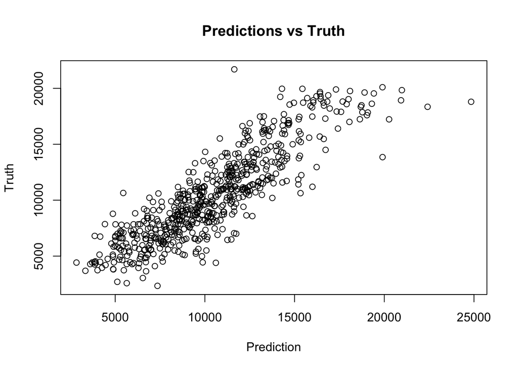

```r
model = lm(as.formula(paste("Outstate~", paste(possible_features[optimal_features], collapse="+"))), data=train);

plot(predict(model, train), train$Outstate, xlab = 'Prediction', ylab='Truth', main='Predictions vs Truth')
```

#### c)

```r
rmse = mean((predict(model, test) - test$Outstate)^2) ^.5
print(paste0('On the test data, the RMSE is ', rmse, ' so the predictions are usually within this far of the true on testing data.'))
```

```
## [1] "On the test data, the RMSE is 1766.20737957773 so the predictions are usually within this far of the true on testing data."
```